# Lab 3 (Part 2) - Descriptive Statistics in R

## Lab Objectives

- Calculate descriptive statistics for continuous and categorical data
- Edit output tables

### Set your working directory

Before getting started, set your working directory to where the course files are located on your computer. The code below is commented out, since you will have to provide your own working directory.

```r
# setwd("Path to your files") # i.e. C:/Users/YourName/Documents/Biometrics Labs/
# note: this depends on your computer's OS
```

In RStudio, you can also change your working directory using the graphical interface:

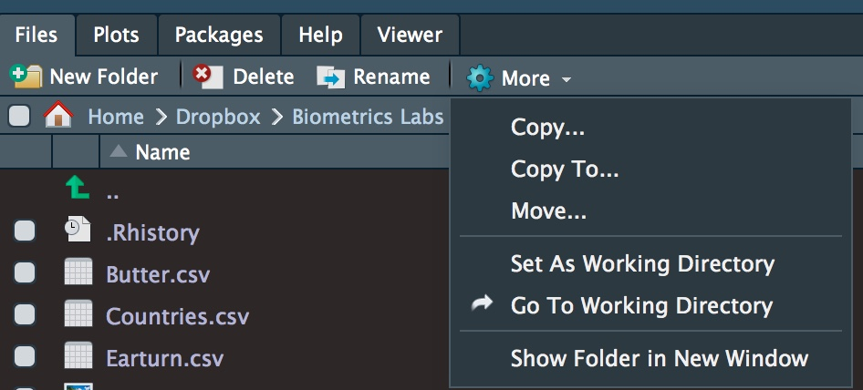

Set your working directory in RStudio

# Exercise 1: Descriptive statistics

Since R is primarily a statistical computing language many descriptive statistics are available simply by coding. More complex approaches involving summarising large datasets can be achieved by installing certain packages.

It is always important to take a moment to think about the type of data you are using and what descriptive statistics will be most useful given the type. For numerical data, you typically report measures of central tendency and measures of variability. It is often useful to observe the frequency distributions or histograms of continuous distributions to note if they are normal or skewed. For categorical data you typically report the frequency or proportion of each value.

## Descriptive Statistics:

Let’s begin by calculating descriptive statistics for some of the data in the Appendix D file.

Open appendixd.csv and examine the structure of the data:

```r
d<-read.csv("appendixd.csv")
str(d)
```

```
## 'data.frame':    88 obs. of  10 variables:
##  $ ID     : int  1 2 3 4 5 6 7 8 9 10 ...
##  $ addsc  : int  45 50 49 55 39 68 69 56 58 48 ...
##  $ gender : Factor w/ 2 levels "female","male": 2 2 2 2 2 2 2 2 2 2 ...
##  $ repeat.: Factor w/ 2 levels "No","Yes": 1 1 1 1 1 2 2 1 1 1 ...
##  $ iq     : int  111 102 108 109 118 79 88 102 105 92 ...
##  $ engl   : int  2 2 2 2 2 2 2 2 3 2 ...
##  $ engg   : int  3 3 4 2 3 2 2 4 1 4 ...
##  $ gpa    : num  2.6 2.75 4 2.25 3 1.67 2.25 3.4 1.33 3.5 ...
##  $ socprob: Factor w/ 2 levels "No","Yes": 1 1 1 1 1 1 2 1 1 1 ...
##  $ dropout: Factor w/ 2 levels "No","Yes": 1 1 1 1 1 2 2 1 1 1 ...
```

## Mean

Calculate the mean of a variable with mean(VAR)

## Standard Deviation

Within R, standard deviations are calculated in the same way as means. The standard deviation of a single variable can be computed with the sd(VAR) command, where VAR is the name of the variable whose standard deviation you wish to retrieve. Similarly, a standard deviation can be calculated for each of the variables in a dataset by using the sd(DATAVAR) command, where DATAVAR is the name of the variable containing the data. The code sample below demonstrates both uses of the standard deviation function.